# Final Project - Nhóm 26 - Project 2

#### 1.2 Xử lý outlier

Xử lý outlier cho từng lớp trong diabetes_012

```r
numeric_vars <- c("bmi", "ment_hlth", "phys_hlth")  # Danh sách các biến định lượng

data <- data %>%
  group_by(diabetes_012) %>%
  mutate(across(
    all_of(numeric_vars),
    ~ ifelse(. < quantile(., 0.25, na.rm = TRUE) - 1.5 * IQR(.),
             quantile(., 0.25, na.rm = TRUE) - 1.5 * IQR(.),
             ifelse(. > quantile(., 0.75, na.rm = TRUE) + 1.5 * IQR(.),
                    quantile(., 0.75, na.rm = TRUE) + 1.5 * IQR(.), .))
  )) %>%
  ungroup()

data
```

```
## # A tibble: 253,680 × 18
##    diabetes_012 high_bp high_chol chol_check   bmi smoker stroke
##    <fct>        <fct>   <fct>     <fct>      <dbl> <fct>  <fct>
##  1 0            1       1         1             39 1      0
##  2 0            0       0         0             25 1      0
##  3 0            1       1         1             28 0      0
##  4 0            1       0         1             27 0      0
##  5 0            1       1         1             24 0      0
##  6 0            1       1         1             25 1      0
##  7 0            1       0         1             30 1      0
##  8 0            1       1         1             25 1      0
##  9 2            1       1         1             30 1      0
## 10 0            0       0         1             24 0      0
## # ℹ 253,670 more rows
## # ℹ 11 more variables: heart_diseaseor_attack <fct>, phys_activity <fct>,
## #   fruits <fct>, veggies <fct>, hvy_alcohol_consump <fct>,
## #   any_healthcare <fct>, no_docbc_cost <fct>, ment_hlth <dbl>,
## #   phys_hlth <dbl>, diff_walk <fct>, sex <fct>
```

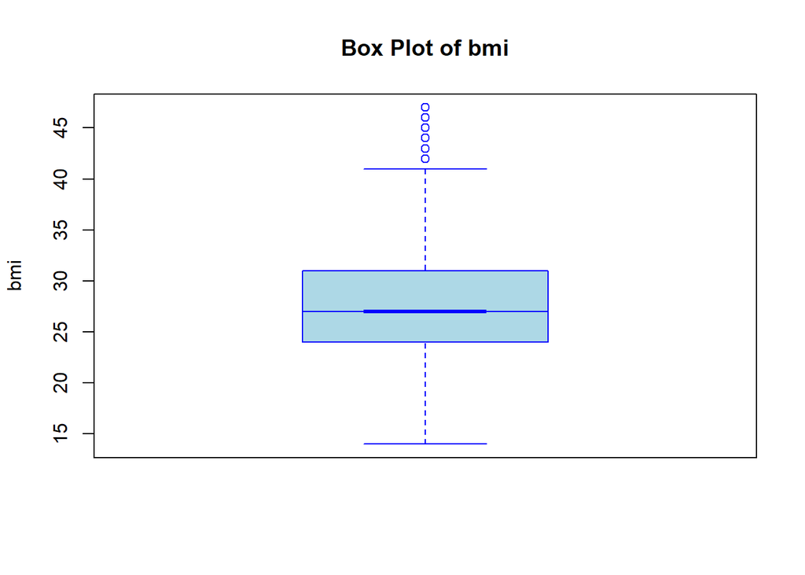

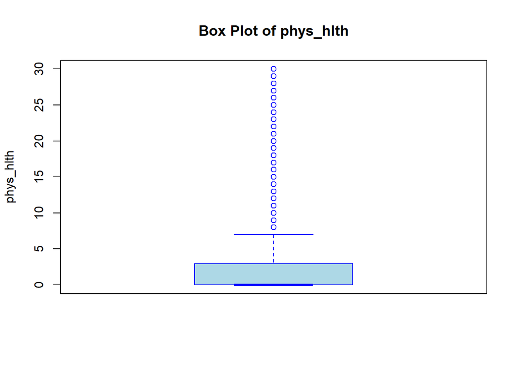

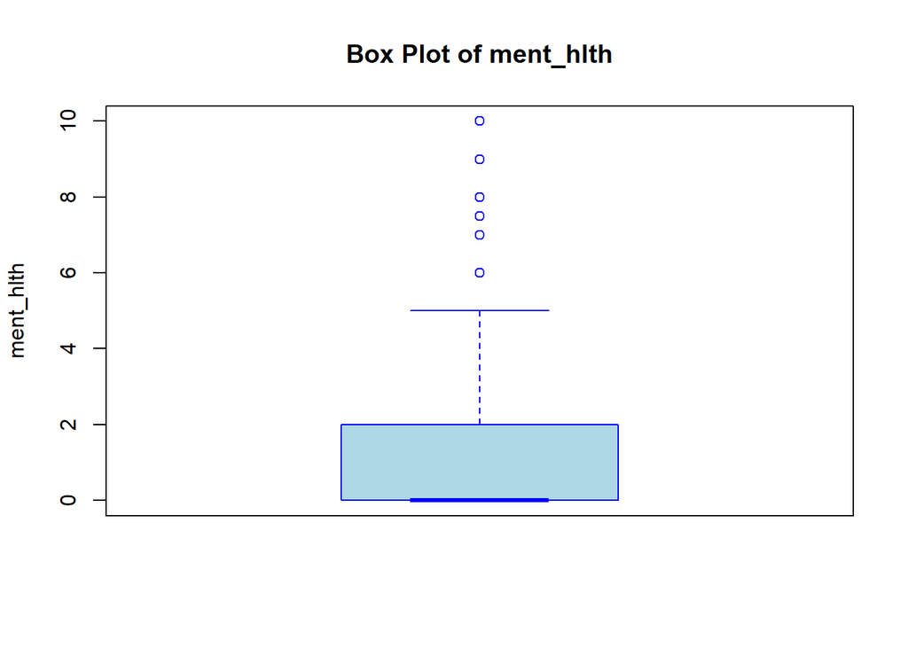

```r
# Vẽ box plot cho từng cột
columns_to_plot <- c("bmi", "phys_hlth", "ment_hlth")

# Lặp qua các cột để vẽ box plot
for (col in columns_to_plot) {
  boxplot(data[[col]],
          main = paste("Box Plot of", col),
          ylab = col,
          col = "lightblue",
          border = "blue",
          notch = TRUE)
}
```

#### 1.3 Xử lý mất cân bằng dữ liệu

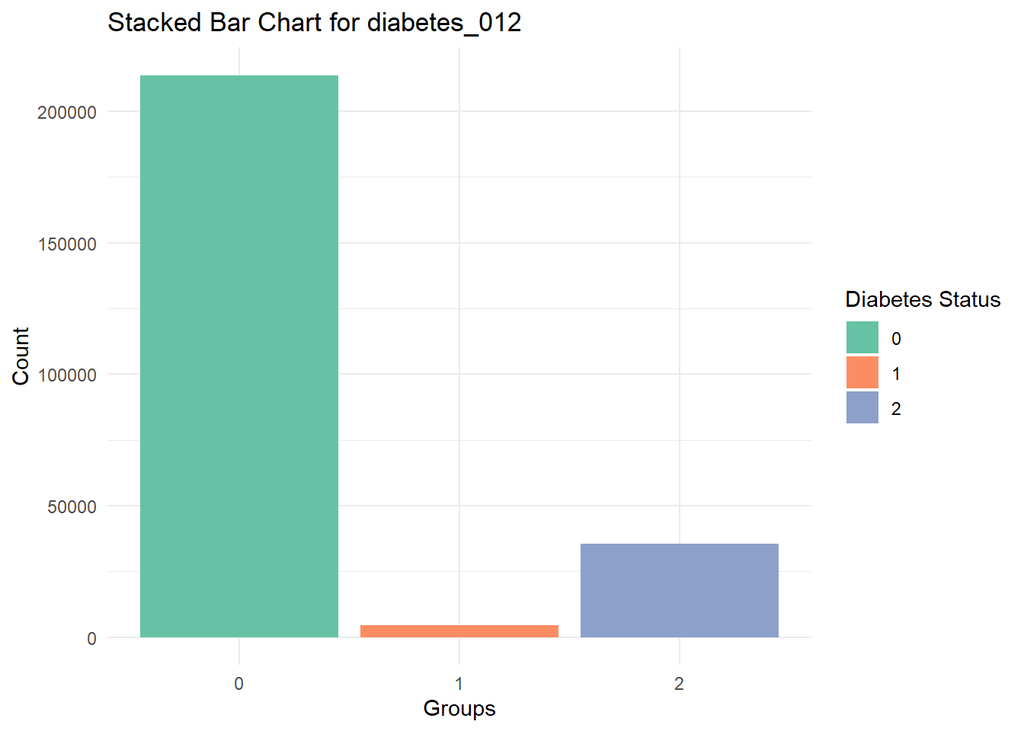

```r
ggplot(data, aes(x = diabetes_012 , fill = as.factor(diabetes_012))) +
  geom_bar(position = "stack") +  # Hiển thị số lượng
  labs(
    title = "Stacked Bar Chart for diabetes_012",
    x = "Groups",
    y = "Count",
    fill = "Diabetes Status"
  ) +
  scale_fill_manual(values = c("#66c2a5", "#fc8d62", "#8da0cb")) +
  theme_minimal()
```

Số lượng người ở nhóm 0 cao hơn rất nhiều so với số lượng người ở nhóm 1 và nhóm 2 nên chúng ta cần phải xử lý dữ liệu bị mất cân bằng này. #### 1.3.1 Phương pháp under-sampling

```r
under_sampling_3c <- function(data, name_class) {
  # Đảm bảo cột phân loại là vector và sau đó chuyển thành factor
  class_fact <- as.factor(data[[name_class]])

  # Tách dữ liệu thành các nhóm dựa trên nhãn lớp
  data_split <- split(data, class_fact)

  # Số lượng mẫu trong từng lớp
  n_class <- sapply(data_split, nrow)
  n_minor <- min(n_class)  # Số lượng mẫu nhỏ nhất

  # Giảm mẫu cho từng lớp
  sampled_data <- lapply(data_split, function(class_data) {
    if (nrow(class_data) > n_minor) {
      # Chọn ngẫu nhiên n_minor mẫu nếu số lượng vượt quá n_minor
      sampled_rows <- sample(seq_len(nrow(class_data)), size = n_minor, replace = FALSE)
      class_data <- class_data[sampled_rows, ]
    }
    return(class_data)
  })

  # Kết hợp lại các lớp
  new_data <- do.call(rbind, sampled_data)
  rownames(new_data) <- NULL  # Reset chỉ số dòng
  return(new_data)
}

data_under <- under_sampling_3c(data, "diabetes_012")
```

```r
table(data_under$diabetes_012)
```

```
##
##    0    1    2
## 4631 4631 4631
```

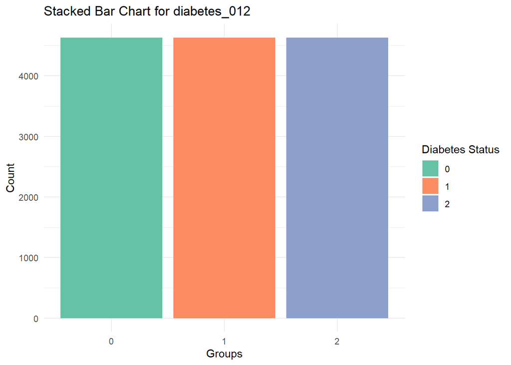

```r
ggplot(data_under, aes(x = diabetes_012 , fill = as.factor(diabetes_012))) +
  geom_bar(position = "stack") +  # Hiển thị số lượng
  labs(
    title = "Stacked Bar Chart for diabetes_012",
    x = "Groups",
    y = "Count",
    fill = "Diabetes Status"
  ) +
  scale_fill_manual(values = c("#66c2a5", "#fc8d62", "#8da0cb")) +
  theme_minimal()
```

#### 1.3.2 Phương pháp over-sampling

```r
over_sampling_multi <- function(data, name_class) {
# Chuyển cột class thành factor
class_fact <- as.factor(data[[name_class]])

# Chia dữ liệu theo từng nhóm
data_split <- split(data, class_fact)

# Đếm số lượng mẫu của từng nhóm
n_class <- sapply(data_split, FUN = nrow)

# Xác định số lượng mẫu lớn nhất
n_max <- max(n_class)

# Tăng cường mẫu cho từng nhóm
new_data <- do.call(rbind, lapply(names(data_split), function(class_name) {
group_data <- data_split[[class_name]]
n_samples <- nrow(group_data)

# Nếu nhóm có ít hơn n_max, thực hiện over-sampling
if (n_samples < n_max) {
id_samples <- sample(1:n_samples, size = n_max, replace = TRUE)
group_data <- group_data[id_samples, ]
}

return(group_data)
}))

return(new_data)
}
```

```r
# Áp dụng phương pháp over-sampling
data_over <- over_sampling_multi(data, "diabetes_012")
```

```r
# Kiểm tra sự mất cân bằng dữ liệu (imbalanced data) cho biến mục tiêu "diabetes_012"
imbalanced_summary <- table(data_over$diabetes_012)
print(imbalanced_summary)
```

```
##
##      0      1      2
## 213703 213703 213703
```

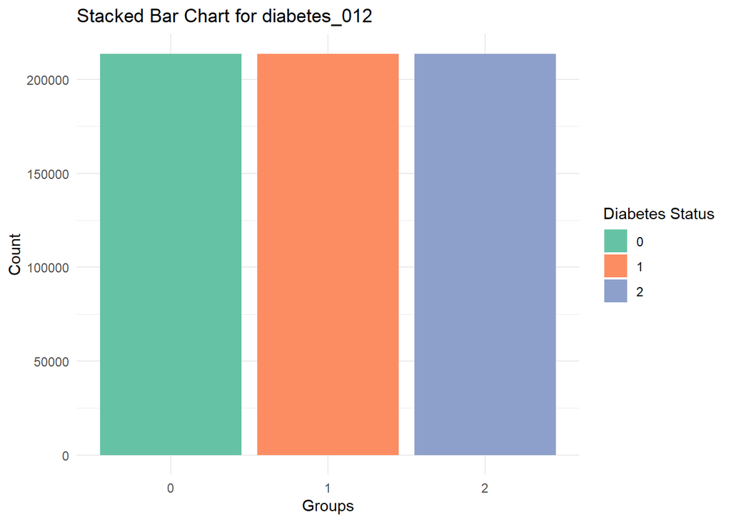

```r
ggplot(data_over, aes(x = diabetes_012 , fill = as.factor(diabetes_012))) +
  geom_bar(position = "stack") +  # Hiển thị số lượng
  labs(
    title = "Stacked Bar Chart for diabetes_012",
    x = "Groups",
    y = "Count",
    fill = "Diabetes Status"
  ) +
  scale_fill_manual(values = c("#66c2a5", "#fc8d62", "#8da0cb")) +
  theme_minimal()
```

#### 1.3.3 Phương pháp SMOTE

```r
table(data$diabetes_012)
```

```
##
##      0      1      2
## 213703   4631  35346
```

```r
glimpse(data)
```

```
## Rows: 253,680
## Columns: 18
## $ diabetes_012           <fct> 0, 0, 0, 0, 0, 0, 0, 0, 2, 0, 2, 0, 0, 2, 0, 0,…
## $ high_bp                <fct> 1, 0, 1, 1, 1, 1, 1, 1, 1, 0, 0, 1, 0, 1, 0, 1,…
## $ high_chol              <fct> 1, 0, 1, 0, 1, 1, 0, 1, 1, 0, 0, 1, 0, 1, 1, 0,…
## $ chol_check             <fct> 1, 0, 1, 1, 1, 1, 1, 1, 1, 1, 1, 1, 1, 1, 1, 1,…
## $ bmi                    <dbl> 39, 25, 28, 27, 24, 25, 30, 25, 30, 24, 25, 34,…
## $ smoker                 <fct> 1, 1, 0, 0, 0, 1, 1, 1, 1, 0, 1, 1, 1, 0, 1, 0,…
## $ stroke                 <fct> 0, 0, 0, 0, 0, 0, 0, 0, 0, 0, 0, 0, 0, 0, 1, 0,…
## $ heart_diseaseor_attack <fct> 0, 0, 0, 0, 0, 0, 0, 0, 1, 0, 0, 0, 0, 0, 0, 0,…
## $ phys_activity          <fct> 0, 1, 0, 1, 1, 1, 0, 1, 0, 0, 1, 0, 0, 0, 1, 1,…
## $ fruits                 <fct> 0, 0, 1, 1, 1, 1, 0, 0, 1, 0, 1, 1, 0, 0, 0, 0,…
## $ veggies                <fct> 1, 0, 0, 1, 1, 1, 0, 1, 1, 1, 1, 1, 1, 1, 1, 0,…
## $ hvy_alcohol_consump    <fct> 0, 0, 0, 0, 0, 0, 0, 0, 0, 0, 0, 0, 0, 0, 0, 0,…
## $ any_healthcare         <fct> 1, 0, 1, 1, 1, 1, 1, 1, 1, 1, 1, 1, 1, 1, 1, 1,…
## $ no_docbc_cost          <fct> 0, 1, 1, 0, 0, 0, 0, 0, 0, 0, 0, 0, 0, 0, 1, 0,…
## $ ment_hlth              <dbl> 5.0, 0.0, 5.0, 0.0, 3.0, 0.0, 0.0, 0.0, 7.5, 0.…
## $ phys_hlth              <dbl> 5, 0, 5, 0, 0, 2, 5, 0, 30, 0, 0, 5, 5, 0, 5, 0…
## $ diff_walk              <fct> 1, 0, 1, 0, 0, 0, 0, 1, 1, 0, 0, 1, 0, 1, 0, 0,…
## $ sex                    <fct> 0, 0, 0, 0, 0, 1, 0, 0, 0, 1, 1, 0, 0, 0, 0, 0,…
```

```r
data_smote = smotenc(df = data, var = "diabetes_012",
k = 5, over_ratio = 1)
data
```

```
## # A tibble: 253,680 × 18
##    diabetes_012 high_bp high_chol chol_check   bmi smoker stroke
##    <fct>        <fct>   <fct>     <fct>      <dbl> <fct>  <fct>
##  1 0            1       1         1             39 1      0
##  2 0            0       0         0             25 1      0
##  3 0            1       1         1             28 0      0
##  4 0            1       0         1             27 0      0
##  5 0            1       1         1             24 0      0
##  6 0            1       1         1             25 1      0
##  7 0            1       0         1             30 1      0
##  8 0            1       1         1             25 1      0
##  9 2            1       1         1             30 1      0
## 10 0            0       0         1             24 0      0
## # ℹ 253,670 more rows
## # ℹ 11 more variables: heart_diseaseor_attack <fct>, phys_activity <fct>,
## #   fruits <fct>, veggies <fct>, hvy_alcohol_consump <fct>,
## #   any_healthcare <fct>, no_docbc_cost <fct>, ment_hlth <dbl>,
## #   phys_hlth <dbl>, diff_walk <fct>, sex <fct>
```

```r
table(data_smote$diabetes_012)
```

```
##
##      0      1      2
## 213703 213703 213703
```

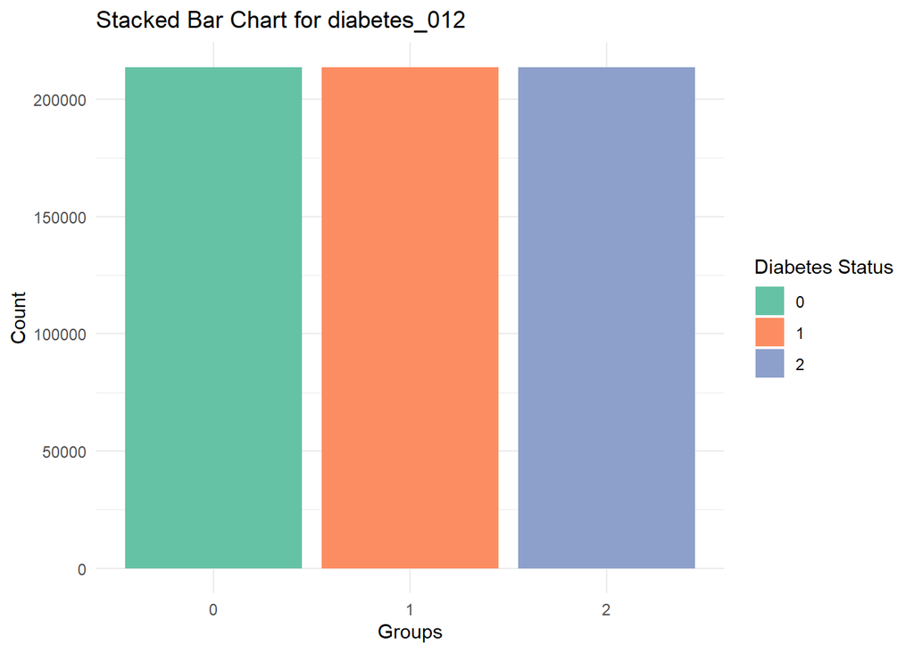

```r
ggplot(data_smote, aes(x = diabetes_012 , fill = as.factor(diabetes_012))) +
  geom_bar(position = "stack") +  # Hiển thị số lượng
  labs(
    title = "Stacked Bar Chart for diabetes_012",
    x = "Groups",
    y = "Count",
    fill = "Diabetes Status"
  ) +
  scale_fill_manual(values = c("#66c2a5", "#fc8d62", "#8da0cb")) +
  theme_minimal()
```

#### 1.4 Chia và chuẩn hóa dữ liệu

```r
# Hàm chia dữ liệu thành train và test
split_random <- function(data, target_col, train_ratio = 0.7) {
  set.seed(86)  # Đặt seed để đảm bảo tính tái lập
  train_index <- createDataPartition(data[[target_col]], p = train_ratio, list = FALSE)
  train_data <- data[train_index, ]
  test_data <- data[-train_index, ]
  list(train = train_data, test = test_data)
}

# Hàm chuẩn hóa dữ liệu (Min-Max Scaling)
normalize_data <- function(train_data, test_data, cols) {
  for (col in cols) {
    min_val <- min(train_data[[col]], na.rm = TRUE)
    max_val <- max(train_data[[col]], na.rm = TRUE)

    # Chuẩn hóa tập huấn luyện
    train_data[[col]] <- (train_data[[col]] - min_val) / (max_val - min_val)

    # Chuẩn hóa tập kiểm tra
    test_data[[col]] <- (test_data[[col]] - min_val) / (max_val - min_val)
  }
  list(train = train_data, test = test_data)
}

# Các cột định lượng cần chuẩn hóa
continuous_cols <- c("bmi", "ment_hlth", "phys_hlth")

# Áp dụng cho từng tập dữ liệu (data_under, data_over, data_smote)
datasets <- list(under = data_under, over = data_over, smote = data_smote)

# Kết quả sau khi chia và chuẩn hóa
processed_data <- lapply(datasets, function(dataset) {
  # Chia dữ liệu thành train và test
  split <- split_random(dataset, target_col = "diabetes_012", train_ratio = 0.7)
  # Chuẩn hóa dữ liệu
  normalize_data(split$train, split$test, continuous_cols)
})


# Truy cập kết quả cho từng tập dữ liệu
train_data_under <- processed_data$under$train
test_data_under <- processed_data$under$test

train_data_over <- processed_data$over$train
test_data_over <- processed_data$over$test

train_data_smote <- processed_data$smote$train
test_data_smote <- processed_data$smote$test

# Kiểm tra phân phối và chuẩn hóa
cat("Under-sampling - Train distribution:\n")
```

```
## Under-sampling - Train distribution:
```

```r
print(table(train_data_under$diabetes_012))
```

```
##
##    0    1    2
## 3242 3242 3242
```

```r
cat("Under-sampling - Test distribution:\n")
```

```
## Under-sampling - Test distribution:
```

```r
print(table(test_data_under$diabetes_012))
```

```
##
##    0    1    2
## 1389 1389 1389
```

```r
cat("\nOver-sampling - Train distribution:\n")
```

```
##
## Over-sampling - Train distribution:
```

```r
print(table(train_data_over$diabetes_012))
```

```
##
##      0      1      2
## 149593 149593 149593
```

```r
cat("Over-sampling - Test distribution:\n")
```

```
## Over-sampling - Test distribution:
```

```r
print(table(test_data_over$diabetes_012))
```

```
##
##     0     1     2
## 64110 64110 64110
```

```r
cat("\nSMOTE - Train distribution:\n")
```

```
##
## SMOTE - Train distribution:
```

```r
print(table(train_data_smote$diabetes_012))
```

```
##
##      0      1      2
## 149593 149593 149593
```

```r
cat("SMOTE - Test distribution:\n")
```

```
## SMOTE - Test distribution:
```

```r
print(table(test_data_smote$diabetes_012))
```

```
##
##     0     1     2
## 64110 64110 64110
```

# 2.Xây dựng mô hình phân loại

## 2.1 Phương pháp Naive Bayes

Xây dựng mô hình lần lượt với 3 bộ dữ liệu: Với bộ dữ liệu xử lý bằng phương pháp under-sampling:

```r
# Xây dựng mô hình với lần lượt 3 bộ dữ liệu sau khi xử lý:
# Với dữ liệu xử lý bằng under-sampling
nb_model <- naiveBayes(diabetes_012 ~ ., data = train_data_under)

newdata = test_data_under[, !(colnames(test_data_under) == "diabetes_012")]
# Dự đoán trên tập kiểm tra
predictions <- predict(nb_model, newdata)
# Đánh giá mô hình
conf_matrix <- confusionMatrix(predictions, test_data_under$diabetes_012)
print(conf_matrix)
```

```
## Confusion Matrix and Statistics
##
##           Reference
## Prediction    0    1    2
##          0 1147  747  624
##          1  141  329  200
##          2  101  313  565
##
## Overall Statistics
##
##                Accuracy : 0.4898
##                  95% CI : (0.4745, 0.5051)
##     No Information Rate : 0.3333
##     P-Value [Acc > NIR] : < 2.2e-16
##
##                   Kappa : 0.2347
##
##  Mcnemar's Test P-Value : < 2.2e-16
##
## Statistics by Class:
##
##                      Class: 0 Class: 1 Class: 2
## Sensitivity            0.8258  0.23686   0.4068
## Specificity            0.5065  0.87725   0.8510
## Pos Pred Value         0.4555  0.49104   0.5771
## Neg Pred Value         0.8532  0.69688   0.7415
## Prevalence             0.3333  0.33333   0.3333
## Detection Rate         0.2753  0.07895   0.1356
## Detection Prevalence   0.6043  0.16079   0.2349
## Balanced Accuracy      0.6661  0.55706   0.6289
```

```r
# Với dữ liệu xử lý bằng over-sampling
nb_model <- naiveBayes(diabetes_012 ~ ., data = train_data_over)

newdata = test_data_over[, !(colnames(test_data_over) == "diabetes_012")]
# Dự đoán trên tập kiểm tra
predictions <- predict(nb_model, newdata)
# Đánh giá mô hình
conf_matrix <- confusionMatrix(predictions, test_data_over$diabetes_012)

print(conf_matrix)
```

```
## Confusion Matrix and Statistics
##
##           Reference
## Prediction     0     1     2
##          0 53422 33666 28377
##          1  6418 15296  8665
##          2  4270 15148 27068
##
## Overall Statistics
##
##                Accuracy : 0.498
##                  95% CI : (0.4958, 0.5003)
##     No Information Rate : 0.3333
##     P-Value [Acc > NIR] : < 2.2e-16
##
##                   Kappa : 0.247
##
##  Mcnemar's Test P-Value : < 2.2e-16
##
## Statistics by Class:
##
##                      Class: 0 Class: 1 Class: 2
## Sensitivity            0.8333  0.23859   0.4222
## Specificity            0.5161  0.88237   0.8486
## Pos Pred Value         0.4627  0.50351   0.5823
## Neg Pred Value         0.8610  0.69859   0.7460
## Prevalence             0.3333  0.33333   0.3333
## Detection Rate         0.2778  0.07953   0.1407
## Detection Prevalence   0.6003  0.15795   0.2417
## Balanced Accuracy      0.6747  0.56048   0.6354
```

```r
# Với dữ liệu xử lý bằng smote-sampling
nb_model <- naiveBayes(diabetes_012 ~ ., data = train_data_smote)

newdata = test_data_smote[, !(colnames(test_data_smote) == "diabetes_012")]
# Dự đoán trên tập kiểm tra
predictions <- predict(nb_model, newdata)
# Đánh giá mô hình
conf_matrix <- confusionMatrix(predictions, test_data_smote$diabetes_012)
print(conf_matrix)
```

```
## Confusion Matrix and Statistics
##
##           Reference
## Prediction     0     1     2
##          0 52935 35734 28811
##          1  6920 13150  8458
##          2  4255 15226 26841
##
## Overall Statistics
##
##                Accuracy : 0.4832
##                  95% CI : (0.4809, 0.4854)
##     No Information Rate : 0.3333
##     P-Value [Acc > NIR] : < 2.2e-16
##
##                   Kappa : 0.2247
##
##  Mcnemar's Test P-Value : < 2.2e-16
##
## Statistics by Class:
##
##                      Class: 0 Class: 1 Class: 2
## Sensitivity            0.8257  0.20512   0.4187
## Specificity            0.4966  0.88007   0.8481
## Pos Pred Value         0.4506  0.46095   0.5794
## Neg Pred Value         0.8507  0.68889   0.7447
## Prevalence             0.3333  0.33333   0.3333
## Detection Rate         0.2752  0.06837   0.1396
## Detection Prevalence   0.6108  0.14833   0.2408
## Balanced Accuracy      0.6611  0.54259   0.6334
```

Vẽ ROC và tính AUC để đánh giá 3 mô hình trên.

```r
# Hàm tính và vẽ đường ROC
plot_roc <- function(model, test_data, target_col) {
  # Loại cột mục tiêu khỏi dữ liệu kiểm tra
  newdata <- test_data[, !(colnames(test_data) == target_col)]

  # Tính toán xác suất dự đoán
  prob_predictions <- predict(model, newdata, type = "raw")

  # Chuyển cột mục tiêu thành dạng numeric
  actual_classes <- as.numeric(test_data[[target_col]]) - 1

  # Vẽ đường ROC cho từng lớp
  roc_list <- lapply(1:ncol(prob_predictions), function(class_index) {
    roc(response = actual_classes == (class_index - 1),
        predictor = prob_predictions[, class_index],
        levels = c(FALSE, TRUE),
        direction = "<")
  })

  # Vẽ các đường ROC trên cùng một biểu đồ
  plot(roc_list[[1]], col = "red", main = "ROC Curve for Classes", legacy.axes = TRUE)
  for (i in 2:length(roc_list)) {
    plot(roc_list[[i]], col = i + 1, add = TRUE)
  }

  # Thêm chú thích
  legend("bottomright", legend = paste("Class", 0:(length(roc_list) - 1)),
         col = 2:(length(roc_list) + 1), lwd = 2)

  # Tính và in AUC cho từng lớp
  auc_values <- sapply(roc_list, function(roc) auc(roc))
  print(paste("AUC for each class:", auc_values))
}

# Vẽ đường ROC cho dữ liệu under-sampling
cat("Under-sampling:\n")
```

```
## Under-sampling:
```

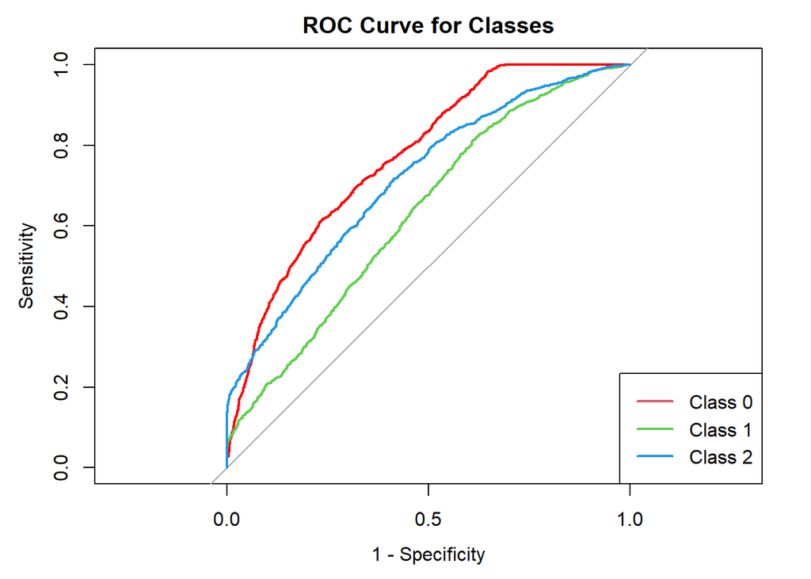

```
## [1] "AUC for each class: 0.770503197757138"
## [2] "AUC for each class: 0.632131848458603"
## [3] "AUC for each class: 0.714270849692716"
```

```r
plot_roc(nb_model, test_data_under, "diabetes_012")
```

```r
# Vẽ đường ROC cho dữ liệu over-sampling
cat("\nOver-sampling:\n")
```

```
##
## Over-sampling:
```

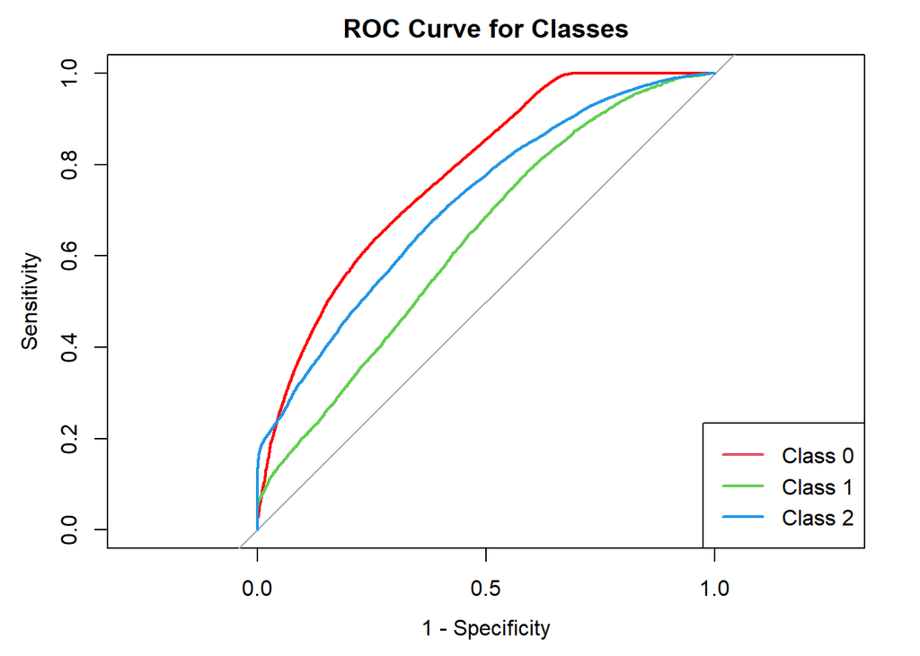

```
## [1] "AUC for each class: 0.777531377885668"
## [2] "AUC for each class: 0.635618984608642"
## [3] "AUC for each class: 0.715772434028911"
```

```r
plot_roc(nb_model, test_data_over, "diabetes_012")
```

```r
# Vẽ đường ROC cho dữ liệu SMOTE
cat("\nSMOTE:\n")
```

```
##
## SMOTE:
```

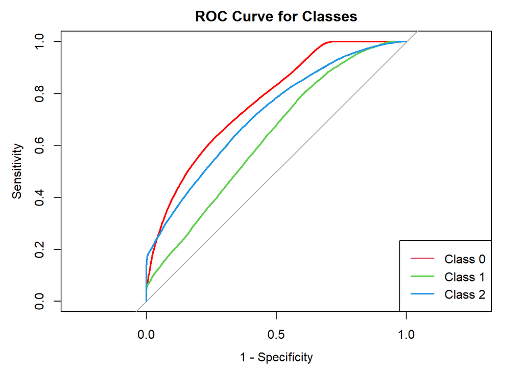

```
## [1] "AUC for each class: 0.769111452940434"
## [2] "AUC for each class: 0.63332027669161"
## [3] "AUC for each class: 0.718919619647939"
```

```r
plot_roc(nb_model, test_data_smote, "diabetes_012")
```

Nhận thấy kết quả của việc phân loại bằng phương pháp Naive Bayes không được khả quan, chúng ta kiểm tra lại các giả định ban đầu của phương pháp đã được thỏa hay chưa: + Giả định phân phối của biến là phân phối chuẩn:

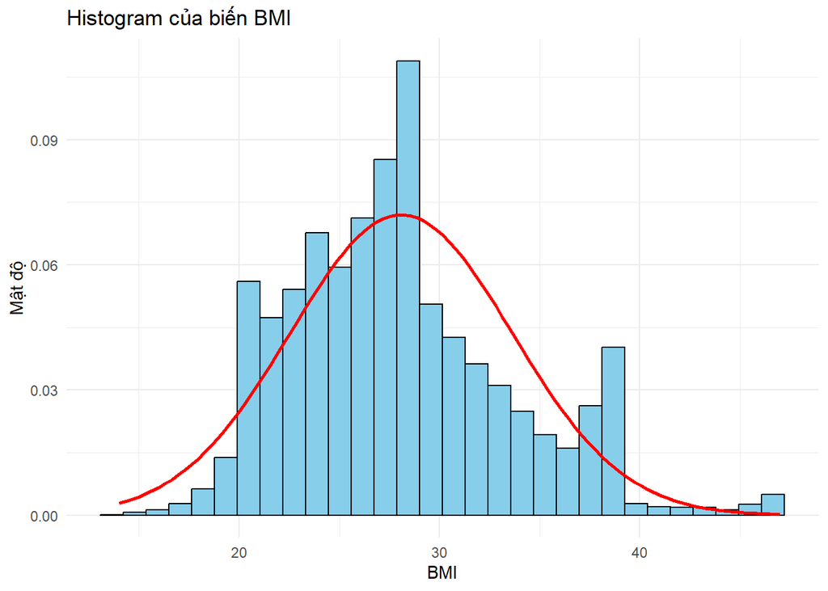

```r
ggplot(data, aes(x = bmi)) +
  geom_histogram(aes(y = ..density..), bins = 30, fill = "skyblue", color = "black") +
  stat_function(fun = dnorm,
                args = list(mean = mean(data$bmi, na.rm = TRUE),
                            sd = sd(data$bmi, na.rm = TRUE)),
                color = "red", linewidth = 1) +
  labs(title = "Histogram của biến BMI", x = "BMI", y = "Mật độ") +
  theme_minimal()
```

Do histogram không đối xứng và có đuôi dài về phía phải, dữ liệu không phải là phân phối chuẩn. Dữ liệu không tuân theo phân phối chuẩn.

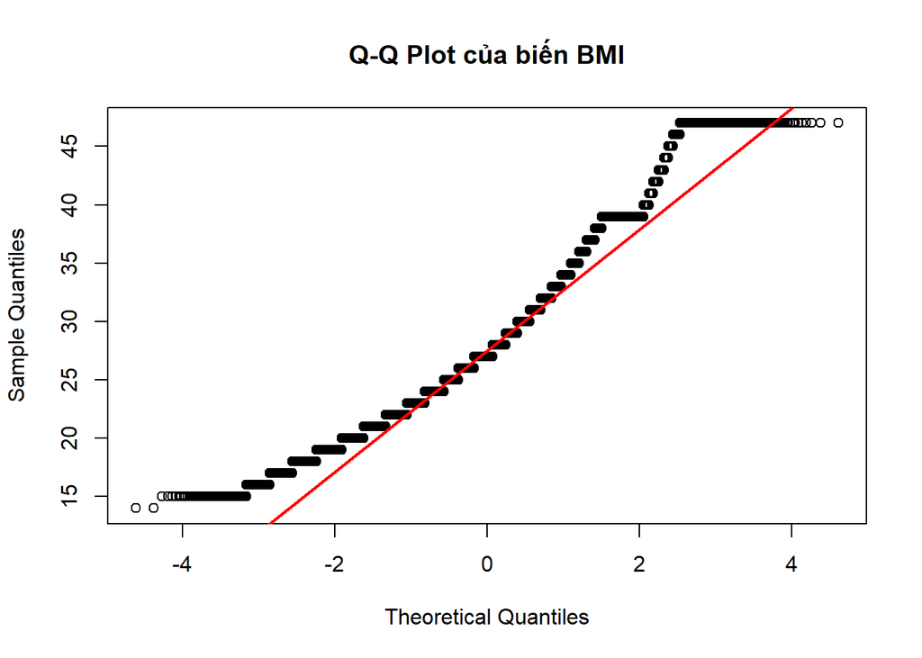

```r
qqnorm(data$bmi, main = "Q-Q Plot của biến BMI")
qqline(data$bmi, col = "red", lwd = 2)
```

Dữ liệu dữ liệu có sự lệch đáng kể so với đường màu đỏ, dữ liệu BMI không có phân phối chuẩn. Không thỏa giả định của phương pháp Naive Bayes.

### 2.2 Phương pháp Discriminant Analysis

#### 2.2.1 Linear Discriminant Analysis

```r
# Hàm đánh giá
eval_multi_class <- function(conf_matrix) {
  cc <- sum(diag(conf_matrix))
  sc <- sum(conf_matrix)
  pp <- colSums(conf_matrix)
  tt <- rowSums(conf_matrix)

  prec <- diag(conf_matrix) / colSums(conf_matrix)
  recall <- diag(conf_matrix) / rowSums(conf_matrix)
  macro_prec <- mean(prec, na.rm = TRUE)
  macro_recall <- mean(recall, na.rm = TRUE)
  macro_f1 <- 2 * macro_prec * macro_recall / (macro_prec + macro_recall)
  acc <- cc / sc
  kap <- (cc * sc - sum(pp * tt)) / (sc^2 - sum(pp * tt))

  list(
    Precision = prec,
    Recall = recall,
    Accuracy = acc,
    Kappa = kap,
    Macro_F1 = macro_f1
  )
}
```

```r
# Hàm tính và vẽ đường ROC
plot_roc <- function(prob_predictions, actual_classes) {
  # Vẽ đường ROC cho từng lớp
  roc_list <- lapply(1:ncol(prob_predictions), function(class_index) {
    roc(response = actual_classes == (class_index - 1),
        predictor = prob_predictions[, class_index],
        levels = c(FALSE, TRUE),
        direction = "<")
  })

  # Vẽ các đường ROC trên cùng một biểu đồ
  plot(roc_list[[1]], col = "red", main = "ROC Curve for Classes", legacy.axes = TRUE)
  for (i in 2:length(roc_list)) {
    plot(roc_list[[i]], col = i + 1, add = TRUE)
  }

  # Thêm chú thích
  legend("bottomright", legend = paste("Class", 0:(length(roc_list) - 1)),
         col = 2:(length(roc_list) + 1), lwd = 2)

  # Tính và in AUC cho từng lớp
  auc_values <- sapply(roc_list, function(roc) auc(roc))
  print(paste("AUC for each class:", auc_values))
}
```

Thực hiện với bộ dữ liệu được xử lý bằng phương pháp under-sampling:

```r
# train_data_under
# LDA
lda_model <- lda(diabetes_012 ~ ., data = train_data_under)

lda_predictions <- predict(lda_model, newdata = test_data_under)
lda_class <- lda_predictions$class
lda_posterior <- lda_predictions$posterior

# Confusion Matrix
conf_matrix_lda <- table(test_data_under$diabetes_012, lda_class)
conf_matrix_lda
```

```
##    lda_class
##       0   1   2
##   0 965 275 149
##   1 446 516 427
##   2 303 384 702
```

```r
eval_multi_class(conf_matrix_lda)
```

```
## $Precision
##         0         1         2
## 0.5630105 0.4391489 0.5492958
##
## $Recall
##         0         1         2
## 0.6947444 0.3714903 0.5053996
##
## $Accuracy
## [1] 0.5238781
##
## $Kappa
## [1] 0.2858171
##
## $Macro_F1
## [1] 0.5204932
```

```r
# Chuyển đổi cột mục tiêu thành dạng numeric
actual_classes <- as.numeric(test_data_under$diabetes_012) - 1

# Vẽ đường ROC và tính AUC cho mô hình LDA
cat("Under-sampling - LDA:\n")
```

```
## Under-sampling - LDA:
```

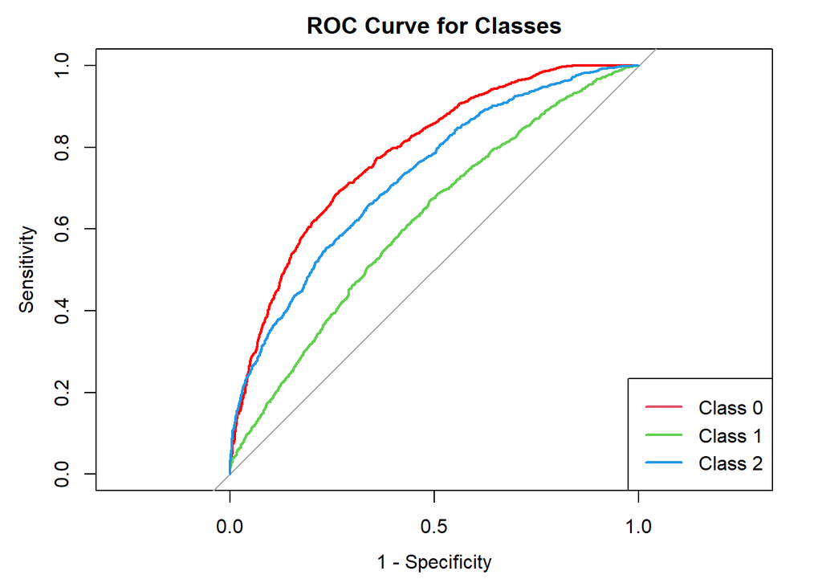

```
## [1] "AUC for each class: 0.784060298934185"
## [2] "AUC for each class: 0.618577079708353"
## [3] "AUC for each class: 0.727758237224391"
```

```r
plot_roc(lda_posterior, actual_classes)
```

Thực hiện trên bộ dữ liệu xử lý bằng phương pháp over-sampling:

```r
# train_data_over
# LDA
lda_model <- lda(diabetes_012 ~ ., data = train_data_over)

newdata = test_data_over[, !(colnames(test_data_over) == "diabetes_012")]
# Dự đoán trên tập kiểm tra
predictions <- predict(lda_model, newdata)$class
# Đánh giá mô hình
conf_matrix <- confusionMatrix(predictions, test_data_over$diabetes_012)
print(conf_matrix)
```

```
## Confusion Matrix and Statistics
##
##           Reference
## Prediction     0     1     2
##          0 44087 19900 14008
##          1 12612 23072 16599
##          2  7411 21138 33503
##
## Overall Statistics
##
##                Accuracy : 0.5234
##                  95% CI : (0.5211, 0.5256)
##     No Information Rate : 0.3333
##     P-Value [Acc > NIR] : < 2.2e-16
##
##                   Kappa : 0.2851
##
##  Mcnemar's Test P-Value : < 2.2e-16
##
## Statistics by Class:
##
##                      Class: 0 Class: 1 Class: 2
## Sensitivity            0.6877   0.3599   0.5226
## Specificity            0.7355   0.7722   0.7773
## Pos Pred Value         0.5653   0.4413   0.5399
## Neg Pred Value         0.8249   0.7070   0.7651
## Prevalence             0.3333   0.3333   0.3333
## Detection Rate         0.2292   0.1200   0.1742
## Detection Prevalence   0.4055   0.2718   0.3226
## Balanced Accuracy      0.7116   0.5660   0.6500
```

```r
# Dự đoán xác suất và lớp
lda_predictions <- predict(lda_model, newdata)
lda_posterior <- lda_predictions$posterior

# Chuyển đổi cột mục tiêu thành dạng numeric
actual_classes <- as.numeric(test_data_over$diabetes_012) - 1

# Vẽ đường ROC và tính AUC
cat("Over-sampling - LDA:\n")
```

```
## Over-sampling - LDA:
```

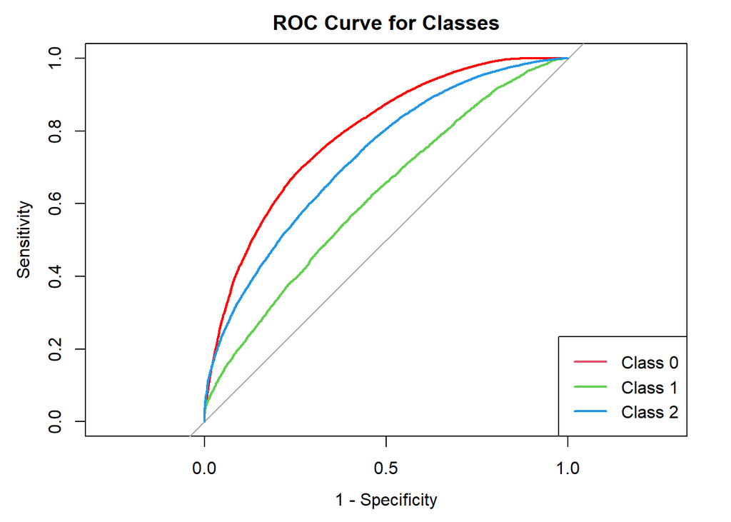

```
## [1] "AUC for each class: 0.791670807510615"
## [2] "AUC for each class: 0.621182013719352"
## [3] "AUC for each class: 0.729070961451204"
```

```r
plot_roc(lda_posterior, actual_classes)
```

Thực hiện với bộ dữ liệu được xử lý bằng phương pháp SMOTE:

```r
# train_data_smote
# LDA
lda_model <- lda(diabetes_012 ~ ., data = train_data_smote)

newdata = test_data_smote[, !(colnames(test_data_over) == "diabetes_012")]
# Dự đoán trên tập kiểm tra
predictions <- predict(lda_model, newdata)$class
# Đánh giá mô hình
conf_matrix <- confusionMatrix(predictions, test_data_smote$diabetes_012)
print(conf_matrix)
```

```
## Confusion Matrix and Statistics
##
##           Reference
## Prediction     0     1     2
##          0 43067 18554 12842
##          1 14643 27297 20238
##          2  6400 18259 31030
##
## Overall Statistics
##
##                Accuracy : 0.5272
##                  95% CI : (0.525, 0.5294)
##     No Information Rate : 0.3333
##     P-Value [Acc > NIR] : < 2.2e-16
##
##                   Kappa : 0.2908
##
##  Mcnemar's Test P-Value : < 2.2e-16
##
## Statistics by Class:
##
##                      Class: 0 Class: 1 Class: 2
## Sensitivity            0.6718   0.4258   0.4840
## Specificity            0.7551   0.7280   0.8077
## Pos Pred Value         0.5784   0.4390   0.5572
## Neg Pred Value         0.8215   0.7172   0.7579
## Prevalence             0.3333   0.3333   0.3333
## Detection Rate         0.2239   0.1419   0.1613
## Detection Prevalence   0.3872   0.3233   0.2895
## Balanced Accuracy      0.7135   0.5769   0.6458
```

```r
# Dự đoán xác suất và lớp
lda_predictions <- predict(lda_model, newdata)
lda_posterior <- lda_predictions$posterior

# Chuyển đổi cột mục tiêu thành dạng numeric
actual_classes <- as.numeric(test_data_smote$diabetes_012) - 1

# Vẽ đường ROC và tính AUC
cat("Over-sampling - LDA:\n")
```

```
## Over-sampling - LDA:
```

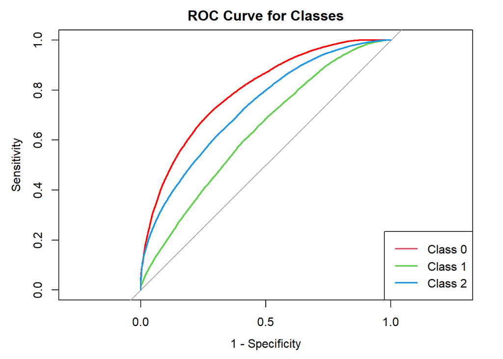

```
## [1] "AUC for each class: 0.793674356044236"
## [2] "AUC for each class: 0.634049284686346"
## [3] "AUC for each class: 0.73017224802578"
```

```r
plot_roc(lda_posterior, actual_classes)
```

#### 2.2.2 Quadratic Discriminant Analysis

Thực hiện với dữ liệu xử lý bằng under-sampling:

```r
# QDA
# train_data_under
qda_model <- qda(diabetes_012 ~ ., data = train_data_under)

qda_predictions <- predict(qda_model, newdata = test_data_under)
qda_class <- qda_predictions$class
qda_posterior <- qda_predictions$posterior

# Confusion Matrix
conf_matrix_qda <- table(test_data_under$diabetes_012, qda_class)
conf_matrix_qda
```

```
##    qda_class
##        0    1    2
##   0 1001  173  215
##   1  596  345  448
##   2  454  191  744
```

```r
eval_multi_class(conf_matrix_qda)
```

```
## $Precision
##         0         1         2
## 0.4880546 0.4866008 0.5287846
##
## $Recall
##         0         1         2
## 0.7206623 0.2483801 0.5356371
##
## $Accuracy
## [1] 0.5015599
##
## $Kappa
## [1] 0.2523398
##
## $Macro_F1
## [1] 0.5013532
```

```r
# Chuyển đổi cột mục tiêu thành dạng numeric
actual_classes <- as.numeric(test_data_under$diabetes_012) - 1

# Vẽ đường ROC và tính AUC cho mô hình LDA
cat("Under-sampling - LDA:\n")
```

```
## Under-sampling - LDA:
```

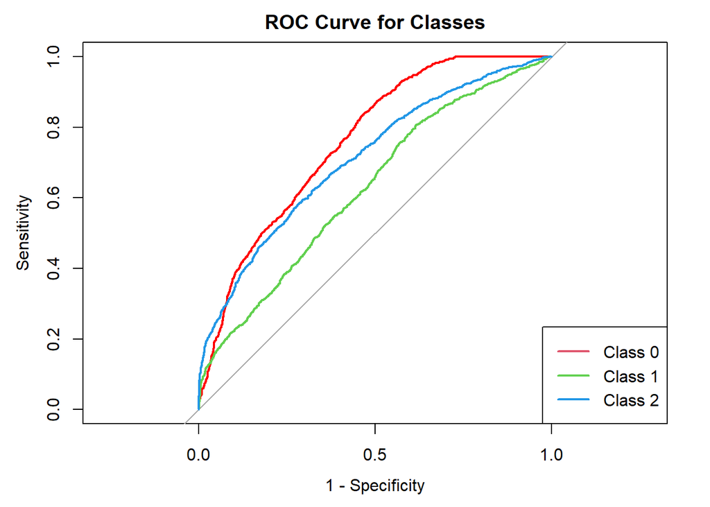

```
## [1] "AUC for each class: 0.75989311783783"
## [2] "AUC for each class: 0.627457924316379"
## [3] "AUC for each class: 0.710726856754267"
```

```r
plot_roc(qda_posterior, actual_classes)
```

Thực hiện với dữ liệu xử lý bằng over-sampling:

```r
# Với dữ liệu xử lý bằng over-sampling
qda_model <- qda(diabetes_012 ~ ., data = train_data_over)

newdata = test_data_over[, !(colnames(test_data_over) == "diabetes_012")]
# Dự đoán trên tập kiểm tra
predictions <- predict(qda_model, newdata)$class
# Đánh giá mô hình
conf_matrix <- confusionMatrix(predictions, test_data_over$diabetes_012)
print(conf_matrix)
```

```
## Confusion Matrix and Statistics
##
##           Reference
## Prediction     0     1     2
##          0 46907 27185 21655
##          1  6339 14489  7341
##          2 10864 22436 35114
##
## Overall Statistics
##
##                Accuracy : 0.5018
##                  95% CI : (0.4996, 0.504)
##     No Information Rate : 0.3333
##     P-Value [Acc > NIR] : < 2.2e-16
##
##                   Kappa : 0.2527
##
##  Mcnemar's Test P-Value : < 2.2e-16
##
## Statistics by Class:
##
##                      Class: 0 Class: 1 Class: 2
## Sensitivity            0.7317  0.22600   0.5477
## Specificity            0.6191  0.89331   0.7403
## Pos Pred Value         0.4899  0.51436   0.5133
## Neg Pred Value         0.8219  0.69773   0.7660
## Prevalence             0.3333  0.33333   0.3333
## Detection Rate         0.2439  0.07533   0.1826
## Detection Prevalence   0.4978  0.14646   0.3557
## Balanced Accuracy      0.6754  0.55966   0.6440
```

```r
# Dự đoán xác suất và lớp
qda_predictions <- predict(lda_model, newdata)
qda_posterior <- qda_predictions$posterior

# Chuyển đổi cột mục tiêu thành dạng numeric
actual_classes <- as.numeric(test_data_over$diabetes_012) - 1

# Vẽ đường ROC và tính AUC
cat("Over-sampling - LDA:\n")
```

```
## Over-sampling - LDA:
```

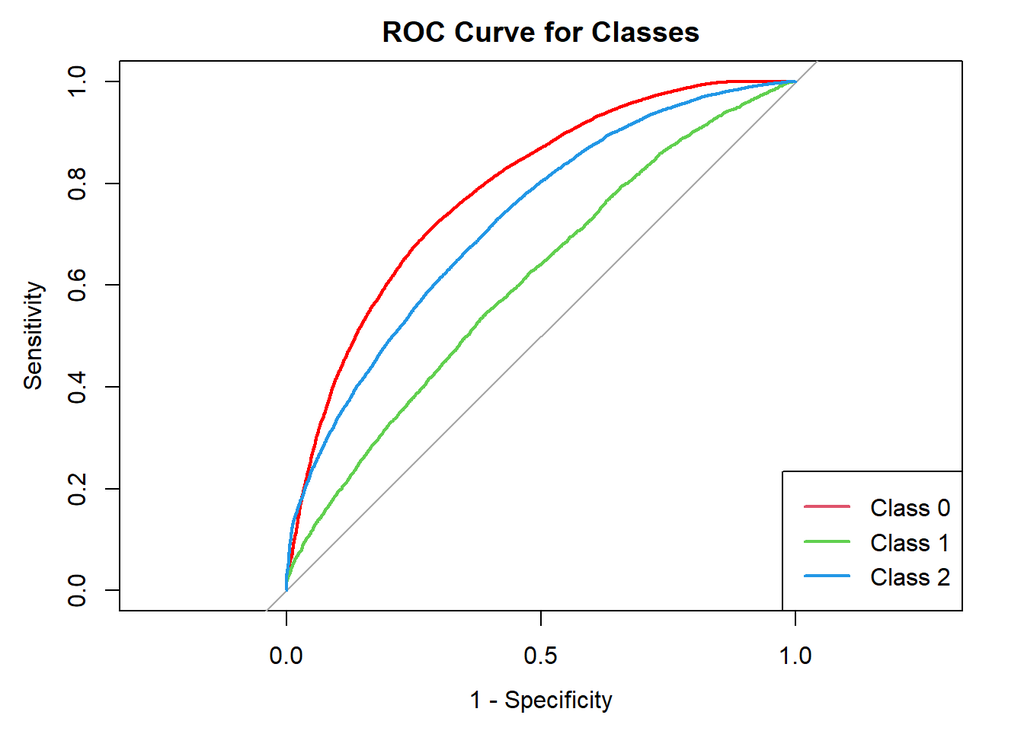

```
## [1] "AUC for each class: 0.787147663613183"
## [2] "AUC for each class: 0.609370249695865"
## [3] "AUC for each class: 0.72758736489141"
```

```r
plot_roc(qda_posterior, actual_classes)
```

Thực hiện với dữ liệu xử lý bằng smote-sampling:

```r
# Với dữ liệu xử lý bằng smote-sampling
qda_model <- qda(diabetes_012 ~ ., data = train_data_smote)

newdata = test_data_smote[, !(colnames(test_data_smote) == "diabetes_012")]
# Dự đoán trên tập kiểm tra
predictions <- predict(qda_model, newdata)$class
# Đánh giá mô hình
conf_matrix <- confusionMatrix(predictions, test_data_smote$diabetes_012)
print(conf_matrix)
```

```
## Confusion Matrix and Statistics
##
##           Reference
## Prediction     0     1     2
##          0 26820  8882  5758
##          1 32227 44099 33291
##          2  5063 11129 25061
##
## Overall Statistics
##
##                Accuracy : 0.499
##                  95% CI : (0.4968, 0.5013)
##     No Information Rate : 0.3333
##     P-Value [Acc > NIR] : < 2.2e-16
##
##                   Kappa : 0.2486
##
##  Mcnemar's Test P-Value : < 2.2e-16
##
## Statistics by Class:
##
##                      Class: 0 Class: 1 Class: 2
## Sensitivity            0.4183   0.6879   0.3909
## Specificity            0.8858   0.4890   0.8737
## Pos Pred Value         0.6469   0.4023   0.6075
## Neg Pred Value         0.7528   0.7581   0.7415
## Prevalence             0.3333   0.3333   0.3333
## Detection Rate         0.1394   0.2293   0.1303
## Detection Prevalence   0.2156   0.5699   0.2145
## Balanced Accuracy      0.6521   0.5884   0.6323
```

```r
# Dự đoán xác suất và lớp
qda_predictions <- predict(lda_model, newdata)
qda_posterior <- qda_predictions$posterior

# Chuyển đổi cột mục tiêu thành dạng numeric
actual_classes <- as.numeric(test_data_over$diabetes_012) - 1

# Vẽ đường ROC và tính AUC
cat("Over-sampling - LDA:\n")
```

```
## Over-sampling - LDA:
```

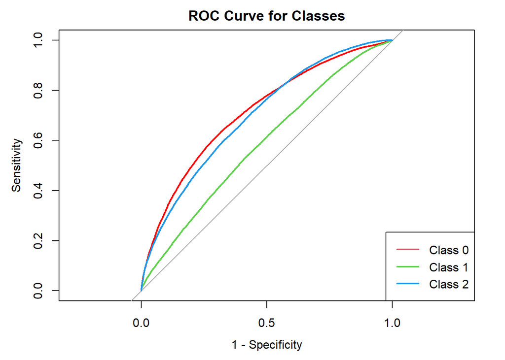

```
## [1] "AUC for each class: 0.712896749625148"
## [2] "AUC for each class: 0.585253788595151"
## [3] "AUC for each class: 0.698696480609279"
```

```r
plot_roc(qda_posterior, actual_classes)
```

### 2.3 Phương pháp Hồi quy Logistic

Thực hiện với bộ dữ liệu được xử lý bằng phương pháp under-sampling: Train mô hình:

```r
X <- train_data_under[, setdiff(colnames(data), "diabetes_012")] # Loại bỏ cột Y
Y <- train_data_under$diabetes_012

model_under_train <- multinom(diabetes_012 ~ ., data = train_data_under, maxit = 1500)
summary(model_under_train)
```

```
## Call:
## multinom(formula = diabetes_012 ~ ., data = train_data_under,
##     maxit = 1500)
##
## Coefficients:
##   (Intercept)  high_bp1 high_chol1 chol_check1      bmi     smoker1     stroke1
## 1   -2.916776 0.6723767  0.6444247   0.9129748 2.276954 -0.02246303 -0.02731408
## 2   -4.080525 1.0555627  0.6984471   1.1885582 3.027963  0.07379680  0.17015385
##   heart_diseaseor_attack1 phys_activity1    fruits1   veggies1
## 1               0.1519372     -0.1101007 0.03563522 -0.1443060
## 2               0.4769548     -0.1239449 0.03463460 -0.1060274
##   hvy_alcohol_consump1 any_healthcare1 no_docbc_cost1  ment_hlth phys_hlth
## 1           -0.4691411      0.10382531      0.2056974  0.7261086  3.083373
## 2           -0.8644100      0.07783244     -0.1074154 -0.1522139  4.274458
##    diff_walk1       sex1
## 1 -0.06811804 0.08665464
## 2 -0.04269997 0.22279420
##
## Std. Errors:
##   (Intercept)   high_bp1 high_chol1 chol_check1       bmi    smoker1   stroke1
## 1   0.2473053 0.05700042 0.05612765   0.1963355 0.1659913 0.05581859 0.1322088
## 2   0.2993196 0.06157804 0.05983385   0.2489671 0.1739759 0.05893886 0.1313400
##   heart_diseaseor_attack1 phys_activity1    fruits1   veggies1
## 1              0.09074767     0.06451815 0.05866285 0.07049582
## 2              0.08965674     0.06743670 0.06206760 0.07422278
##   hvy_alcohol_consump1 any_healthcare1 no_docbc_cost1 ment_hlth phys_hlth
## 1            0.1237911       0.1277950     0.09909834 0.1070820 0.2143986
## 2            0.1478190       0.1403616     0.10903036 0.1168742 0.2147178
##   diff_walk1       sex1
## 1 0.07738887 0.05599928
## 2 0.07962677 0.05922183
##
## Residual Deviance: 18361.28
## AIC: 18433.28
```

```r
pred_class_under_train <- predict(model_under_train, type = "class")
conf_matrix_under_train <- table(Y, pred_class_under_train)
conf_matrix_under_train
```

```
##    pred_class_under_train
## Y      0    1    2
##   0 2275  515  452
##   1 1078  975 1189
##   2  772  682 1788
```

```r
conf_matrix_under_train <- as.matrix(conf_matrix_under_train)
conf_matrix_under_train
```

```
##    pred_class_under_train
## Y      0    1    2
##   0 2275  515  452
##   1 1078  975 1189
##   2  772  682 1788
```

```r
acc_class_under_train <- sum(diag(conf_matrix_under_train))/sum(conf_matrix_under_train)
acc_class_under_train
```

```
## [1] 0.517993
```

```r
prec_class_under_train <- diag(conf_matrix_under_train)/colSums(conf_matrix_under_train)
prec_class_under_train
```

```
##         0         1         2
## 0.5515152 0.4488950 0.5214348
```

```r
recall_class_under_train <- diag(conf_matrix_under_train)/rowSums(conf_matrix_under_train)
recall_class_under_train
```

```
##         0         1         2
## 0.7017273 0.3007403 0.5515114
```

```r
macro_prec_under_train <- mean(prec_class_under_train)
macro_recall_under_train <- mean(recall_class_under_train)
macro_f1_under_train <- 2 * macro_prec_under_train * macro_recall_under_train/(1/macro_prec_under_train + 1/macro_recall_under_train)
macro_f1_under_train
```

```
## [1] 0.1346902
```

```r
eval_multi_class <- function(x) {
  if (!is.matrix(x) && !inherits(x, "table")) {
    stop("lỗi")
  }


  if (inherits(x, "table")) {
    x <- as.matrix(x)
  }

  # Tính toán các thông số
  cc <- sum(diag(x))  # Tổng số dự đoán đúng
  sc <- sum(x)        # Tổng số phần tử
  pp <- colSums(x)    # Tổng số phần tử trong từng cột
  tt <- rowSums(x)    # Tổng số phần tử trong từng hàng

  # Precision và Recall
  prec <- diag(x) / colSums(x)
  recall <- diag(x) / rowSums(x)
  macro_prec <- mean(prec, na.rm = TRUE)
  macro_recall <- mean(recall, na.rm = TRUE)

  # F1-score
  macro_f1 <- 2 * macro_prec * macro_recall / (macro_prec + macro_recall)

  # Accuracy
  acc <- cc / sc

  # Kappa statistic
  kap <- (cc * sc - sum(pp * tt)) / (sc^2 - sum(pp * tt))

  # Trả về kết quả
  return(list(
    Precision = prec,
    Recall = recall,
    Accuracy = acc,
    Kappa = kap,
    Macro_F1 = macro_f1
  ))
}


# Tính toán các chỉ số cho tập huấn luyện
result_under_train <- eval_multi_class(conf_matrix_under_train)
print(result_under_train)
```

```
## $Precision
##         0         1         2
## 0.5515152 0.4488950 0.5214348
##
## $Recall
##         0         1         2
## 0.7017273 0.3007403 0.5515114
##
## $Accuracy
## [1] 0.517993
##
## $Kappa
## [1] 0.2769895
##
## $Macro_F1
## [1] 0.5125814
```

```
Kiểm tra trên tập test:
```

```r
out_prob_mlogit_under_test <- predict(model_under_train, newdata = test_data_under,
type = "probs")
# In ra 5 giá trị đầu tiên
head(out_prob_mlogit_under_test, 5)
```

```
##           0         1         2
## 1 0.6937557 0.1972988 0.1089454
## 2 0.4753676 0.3118122 0.2128202
## 3 0.2320888 0.4376419 0.3302693
## 4 0.5089009 0.2742023 0.2168967
## 5 0.6140243 0.2525177 0.1334580
```

```r
out_class_mlogit_under_test <- predict(model_under_train, newdata = test_data_under,
type = "class")
head(out_class_mlogit_under_test,5)
```

```
## [1] 0 0 1 0 0
## Levels: 0 1 2
```

```r
conf_matrix_under_test <- table(test_data_under$diabetes_012, out_class_mlogit_under_test)

#  Hiển thị confusion matrix
conf_matrix_under_test
```

```
##    out_class_mlogit_under_test
##       0   1   2
##   0 984 211 194
##   1 466 429 494
##   2 322 294 773
```

```r
acc_class_under_test <- sum(diag(conf_matrix_under_test))/sum(conf_matrix_under_test)
acc_class_under_test
```

```
## [1] 0.524598
```

```r
eval_multi_class <- function(x) {
  if (!is.matrix(x) && !inherits(x, "table")) {
    stop("Input phải là ma trận hoặc bảng tần suất!")
  }

  if (inherits(x, "table")) {
    x <- as.matrix(x)
  }

  # Chuẩn hóa ma trận nếu cần
  sc <- sum(x)  # Tổng số phần tử
  if (sc > 1e7) {  # Nếu tổng quá lớn, chuẩn hóa ma trận
    x <- x / sc
    message("Ma trận được chuẩn hóa để tránh overflow.")
  }

  # Tính toán các thông số
  cc <- sum(diag(x))  # Tổng số dự đoán đúng
  pp <- colSums(x)    # Tổng số phần tử trong từng cột
  tt <- rowSums(x)    # Tổng số phần tử trong từng hàng

  # Precision và Recall
  prec <- diag(x) / colSums(x)
  recall <- diag(x) / rowSums(x)
  macro_prec <- mean(prec, na.rm = TRUE)
  macro_recall <- mean(recall, na.rm = TRUE)

  # F1-score
  macro_f1 <- 2 * macro_prec * macro_recall / (macro_prec + macro_recall)

  # Accuracy
  acc <- cc / sc

  # Tính Kappa
  expected_accuracy <- sum(tt * pp) / sc^2
  kappa <- (acc - expected_accuracy) / (1 - expected_accuracy)

  # Trả về kết quả
  return(list(
    Precision = prec,
    Recall = recall,
    Accuracy = acc,
    Macro_F1 = macro_f1,
    Kappa = kappa
  ))
}

eval_multi_class(conf_matrix_under_test)
```

```
## $Precision
##         0         1         2
## 0.5553047 0.4593148 0.5290897
##
## $Recall
##         0         1         2
## 0.7084233 0.3088553 0.5565155
##
## $Accuracy
## [1] 0.524598
##
## $Macro_F1
## [1] 0.5195355
##
## $Kappa
## [1] 0.286897
```

Thực hiện với bộ dữ liệu được xử lý bằng phương pháp over-sampling: Train mô hình:

```r
X <- train_data_over[, setdiff(colnames(data), "diabetes_012")] # Loại bỏ cột Y
Y <- train_data_over$diabetes_012

model_over_train <- multinom(diabetes_012 ~ ., data = train_data_over, maxit = 1500)
summary(model_over_train)
```

```
## Call:
## multinom(formula = diabetes_012 ~ ., data = train_data_over,
##     maxit = 1500)
##
## Coefficients:
##   (Intercept)  high_bp1 high_chol1 chol_check1      bmi    smoker1    stroke1
## 1   -2.973844 0.6512281  0.6475142    0.935338 2.473455 0.05037637 0.06964801
## 2   -4.322788 1.0449228  0.7187206    1.343472 3.245525 0.04787962 0.31587881
##   heart_diseaseor_attack1 phys_activity1     fruits1    veggies1
## 1               0.2211275    -0.08933439  0.04162958 -0.09982891
## 2               0.5168929    -0.12584544 -0.01173547 -0.09209519
##   hvy_alcohol_consump1 any_healthcare1 no_docbc_cost1  ment_hlth phys_hlth
## 1           -0.3150789     -0.02738958     0.12590159  0.7683700  2.959455
## 2           -0.8517455      0.10291578    -0.07792861 -0.1998136  4.097456
##    diff_walk1       sex1
## 1 -0.08376194 0.08317027
## 2  0.01672958 0.21088992
##
## Std. Errors:
##   (Intercept)    high_bp1  high_chol1 chol_check1        bmi     smoker1
## 1   0.0365727 0.008407350 0.008247209  0.02862562 0.02454384 0.008208019
## 2   0.0457881 0.009087488 0.008797895  0.03819995 0.02569458 0.008702131
##      stroke1 heart_diseaseor_attack1 phys_activity1     fruits1   veggies1
## 1 0.02054999              0.01381147    0.009448856 0.008605475 0.01034329
## 2 0.02034241              0.01368822    0.009871170 0.009087855 0.01083959
##   hvy_alcohol_consump1 any_healthcare1 no_docbc_cost1  ment_hlth  phys_hlth
## 1           0.01829549      0.01928007     0.01462507 0.01584626 0.03107335
## 2           0.02271380      0.02153239     0.01593259 0.01742088 0.03113024
##   diff_walk1        sex1
## 1 0.01153384 0.008237352
## 2 0.01179906 0.008735586
##
## Residual Deviance: 844121.8
## AIC: 844193.8
```

```r
pred_class_over_train <- predict(model_over_train, type = "class")
conf_matrix_over_train <- table(Y, pred_class_over_train)
conf_matrix_over_train
```

```
##    pred_class_over_train
## Y        0      1      2
##   0 104936  22802  21855
##   1  49471  44859  55263
##   2  35102  30243  84248
```

```r
conf_matrix_over_train <- as.matrix(conf_matrix_over_train)
head(conf_matrix_over_train,5)
```

```
##    pred_class_over_train
## Y        0      1      2
##   0 104936  22802  21855
##   1  49471  44859  55263
##   2  35102  30243  84248
```

```r
acc_class_over_train <- sum(diag(conf_matrix_over_train))/sum(conf_matrix_over_train)
head(acc_class_over_train,5)
```

```
## [1] 0.5215106
```

```r
eval_multi_class(conf_matrix_over_train)
```

```
## $Precision
##         0         1         2
## 0.5537257 0.4581937 0.5220926
##
## $Recall
##         0         1         2
## 0.7014767 0.2998737 0.5631814
##
## $Accuracy
## [1] 0.5215106
##
## $Macro_F1
## [1] 0.5163739
##
## $Kappa
## [1] 0.2822659
```

```
Kiểm tra trên tập test:
```

```r
out_class_mlogit_over_test <- predict(model_over_train, newdata = test_data_over,
type = "class")
head(out_class_mlogit_over_test,5)
```

```
## [1] 0 0 1 0 0
## Levels: 0 1 2
```

```r
conf_matrix_over_test <- table(test_data_over$diabetes_012, out_class_mlogit_over_test)

# Hiển thị confusion matrix
conf_matrix_over_test
```

```
##    out_class_mlogit_over_test
##         0     1     2
##   0 44999  9607  9504
##   1 21245 19052 23813
##   2 14983 12648 36479
```

```r
acc_class_over_test <- sum(diag(conf_matrix_over_test))/sum(conf_matrix_over_test)
acc_class_over_test
```

```
## [1] 0.5226954
```

```r
eval_multi_class(conf_matrix_over_test)
```

```
## $Precision
##         0         1         2
## 0.5539907 0.4612293 0.5226517
##
## $Recall
##         0         1         2
## 0.7019030 0.2971767 0.5690064
##
## $Accuracy
## [1] 0.5226954
##
## $Macro_F1
## [1] 0.5176107
##
## $Kappa
## [1] 0.2840431
```

Thực hiện với bộ dữ liệu được xử lý bằng phương pháp SMOTE: Train mô hình:

```r
X <- train_data_smote[, setdiff(colnames(data), "diabetes_012")] # Loại bỏ cột Y
Y <- train_data_smote$diabetes_012

model_smote_train <- multinom(diabetes_012 ~ ., data = train_data_smote, maxit = 1500)
summary(model_smote_train)
```

```
## Call:
## multinom(formula = diabetes_012 ~ ., data = train_data_smote,
##     maxit = 1500)
##
## Coefficients:
##   (Intercept)  high_bp1 high_chol1 chol_check1      bmi   smoker1    stroke1
## 1   -5.984692 0.6606172  0.6746003    3.455695 2.616448 0.1133442 -0.6982342
## 2   -5.953065 1.0242276  0.6972745    2.596532 3.690971 0.1012049  0.1114023
##   heart_diseaseor_attack1 phys_activity1       fruits1    veggies1
## 1              0.08173912    -0.09868287  0.0245286787 -0.06238501
## 2              0.47341812    -0.09856064 -0.0004648527 -0.09055824
##   hvy_alcohol_consump1 any_healthcare1 no_docbc_cost1  ment_hlth phys_hlth
## 1           -0.9988996       0.4991554     0.02263477  0.5928995  3.001310
## 2           -1.2154218       0.3197980    -0.12569817 -0.3798476  4.277353
##    diff_walk1       sex1
## 1 -0.12108624 0.07333373
## 2 -0.08551629 0.21007557
##
## Std. Errors:
##   (Intercept)    high_bp1  high_chol1 chol_check1        bmi     smoker1
## 1  0.09043433 0.008487347 0.008297565  0.08647784 0.02649671 0.008254875
## 2  0.07330302 0.009205721 0.008879523  0.06777862 0.02783099 0.008775023
##      stroke1 heart_diseaseor_attack1 phys_activity1     fruits1   veggies1
## 1 0.02349478              0.01420527    0.009523519 0.008661126 0.01043960
## 2 0.02111507              0.01390564    0.009972089 0.009169467 0.01092404
##   hvy_alcohol_consump1 any_healthcare1 no_docbc_cost1  ment_hlth  phys_hlth
## 1           0.02232962      0.02281199     0.01561786 0.01677321 0.03338442
## 2           0.02641495      0.02424143     0.01686058 0.01838987 0.03340559
##   diff_walk1        sex1
## 1 0.01176026 0.008298974
## 2 0.01205802 0.008818890
##
## Residual Deviance: 836959.8
## AIC: 837031.8
```

```r
pred_class_smote_train <- predict(model_smote_train, type = "class")
conf_matrix_smote_train <- table(Y, pred_class_smote_train)
conf_matrix_smote_train
```

```
##    pred_class_smote_train
## Y        0      1      2
##   0 102429  29022  18142
##   1  46284  54243  49066
##   2  32310  38751  78532
```

```r
acc_class_smote_train <- sum(diag(conf_matrix_smote_train))/sum(conf_matrix_smote_train)
acc_class_smote_train
```

```
## [1] 0.5240976
```

```r
eval_multi_class(conf_matrix_smote_train)
```

```
## $Precision
##         0         1         2
## 0.5658342 0.4445565 0.5388500
##
## $Recall
##         0         1         2
## 0.6847179 0.3626039 0.5249711
##
## $Accuracy
## [1] 0.5240976
##
## $Macro_F1
## [1] 0.5202272
##
## $Kappa
## [1] 0.2861464
```

```
Kiểm tra trên tập test:
```

```r
out_class_mlogit_smote_test <- predict(model_smote_train, newdata = test_data_smote,
type = "class")
head(out_class_mlogit_smote_test,5)
```

```
## [1] 0 0 1 1 0
## Levels: 0 1 2
```

```r
conf_matrix_smote_test <- table(test_data_smote$diabetes_012, out_class_mlogit_smote_test)

# 3. Hiển thị ma trận nhầm lẫn
conf_matrix_smote_test
```

```
##    out_class_mlogit_smote_test
##         0     1     2
##   0 44115 12168  7827
##   1 19906 23254 20950
##   2 13912 16494 33704
```

```r
acc_class_smote_test <- sum(diag(conf_matrix_smote_test))/sum(conf_matrix_smote_test)
acc_class_smote_test
```

```
## [1] 0.5255186
```

```r
eval_multi_class(conf_matrix_smote_test)
```

```
## $Precision
##         0         1         2
## 0.5660632 0.4479159 0.5394280
##
## $Recall
##         0         1         2
## 0.6881142 0.3627203 0.5257214
##
## $Accuracy
## [1] 0.5255186
##
## $Macro_F1
## [1] 0.521632
##
## $Kappa
## [1] 0.288278
```

### 2.4 Hồi quy Lasso để lựa chọn biến có ý nghĩa

```r
# Chuẩn bị dữ liệu
X <- model.matrix(diabetes_012 ~ ., data = data)[, -1] # Loại bỏ cột intercept
y <- data$diabetes_012

# Lasso regression với lambda tối ưu
lasso_model <- cv.glmnet(X, y, family = "multinomial", alpha = 1)
print(lasso_model)
```

```
##
## Call:  cv.glmnet(x = X, y = y, family = "multinomial", alpha = 1)
##
## Measure: Multinomial Deviance
##
##        Lambda Index Measure       SE Nonzero
## min 0.0003798    66  0.7448 0.002042      12
## 1se 0.0029409    44  0.7466 0.002011       9
```

```r
# Lấy các biến được chọn
coef(lasso_model, s = "lambda.min")
```

```
## $`0`
## 18 x 1 sparse Matrix of class "dgCMatrix"
##                                   1
## (Intercept)              5.01841488
## high_bp1                -0.58103725
## high_chol1              -0.62298450
## chol_check1             -0.86375824
## bmi                     -0.07263990
## smoker1                 -0.03210758
## stroke1                  .
## heart_diseaseor_attack1 -0.13761714
## phys_activity1           0.01824059
## fruits1                  .
## veggies1                 0.10227452
## hvy_alcohol_consump1     0.25675221
## any_healthcare1          .
## no_docbc_cost1           .
## ment_hlth                .
## phys_hlth               -0.13131214
## diff_walk1               0.09538794
## sex1                    -0.07842954
##
## $`1`
## 18 x 1 sparse Matrix of class "dgCMatrix"
##                                   1
## (Intercept)             -2.76026137
## high_bp1                 .
## high_chol1               .
## chol_check1              .
## bmi                      .
## smoker1                  .
## stroke1                  .
## heart_diseaseor_attack1  .
## phys_activity1           .
## fruits1                  .
## veggies1                 .
## hvy_alcohol_consump1     .
## any_healthcare1          .
## no_docbc_cost1           .
## ment_hlth                0.10438294
```

[output cut: 10 more lines]

```
## chol_check1              0.341205289
## bmi                      0.025033412
## smoker1                  0.023061170
## stroke1                  0.217754924
## heart_diseaseor_attack1  0.286445587
## phys_activity1          -0.026847187
## fruits1                 -0.004386052
## veggies1                -0.005506096
## hvy_alcohol_consump1    -0.522850136
## any_healthcare1          0.049556123
## no_docbc_cost1          -0.194190956
## ment_hlth               -0.021778310
## phys_hlth                0.040091731
## diff_walk1               .
## sex1                     0.104372205
```

```r
data <- data[, !names(data) %in% c("fruits","any_healthcare")]
# Load các thư viện cần thiết
data
```

```
## # A tibble: 253,680 × 16
##    diabetes_012 high_bp high_chol chol_check   bmi smoker stroke
##    <fct>        <fct>   <fct>     <fct>      <dbl> <fct>  <fct>
##  1 0            1       1         1             39 1      0
##  2 0            0       0         0             25 1      0
##  3 0            1       1         1             28 0      0
##  4 0            1       0         1             27 0      0
##  5 0            1       1         1             24 0      0
##  6 0            1       1         1             25 1      0
##  7 0            1       0         1             30 1      0
##  8 0            1       1         1             25 1      0
##  9 2            1       1         1             30 1      0
## 10 0            0       0         1             24 0      0
## # ℹ 253,670 more rows
## # ℹ 9 more variables: heart_diseaseor_attack <fct>, phys_activity <fct>,
## #   veggies <fct>, hvy_alcohol_consump <fct>, no_docbc_cost <fct>,
## #   ment_hlth <dbl>, phys_hlth <dbl>, diff_walk <fct>, sex <fct>
```

```r
under_sampling_3c <- function(data, name_class) {
  # Đảm bảo cột phân loại là vector và sau đó chuyển thành factor
  class_fact <- as.factor(data[[name_class]])

  # Tách dữ liệu thành các nhóm dựa trên nhãn lớp
  data_split <- split(data, class_fact)

  # Số lượng mẫu trong từng lớp
  n_class <- sapply(data_split, nrow)
  n_minor <- min(n_class)  # Số lượng mẫu nhỏ nhất

  # Giảm mẫu cho từng lớp
  sampled_data <- lapply(data_split, function(class_data) {
    if (nrow(class_data) > n_minor) {
      # Chọn ngẫu nhiên n_minor mẫu nếu số lượng vượt quá n_minor
      sampled_rows <- sample(seq_len(nrow(class_data)), size = n_minor, replace = FALSE)
      class_data <- class_data[sampled_rows, ]
    }
    return(class_data)
  })

  # Kết hợp lại các lớp
  new_data <- do.call(rbind, sampled_data)
  rownames(new_data) <- NULL  # Reset chỉ số dòng
  return(new_data)
}

data_under <- under_sampling_3c(data, "diabetes_012")

over_sampling_multi <- function(data, name_class) {
# Chuyển cột class thành factor
class_fact <- as.factor(data[[name_class]])

# Chia dữ liệu theo từng nhóm
data_split <- split(data, class_fact)

# Đếm số lượng mẫu của từng nhóm
n_class <- sapply(data_split, FUN = nrow)

# Xác định số lượng mẫu lớn nhất
n_max <- max(n_class)

# Tăng cường mẫu cho từng nhóm
new_data <- do.call(rbind, lapply(names(data_split), function(class_name) {
group_data <- data_split[[class_name]]
n_samples <- nrow(group_data)

# Nếu nhóm có ít hơn n_max, thực hiện over-sampling
if (n_samples < n_max) {
id_samples <- sample(1:n_samples, size = n_max, replace = TRUE)
group_data <- group_data[id_samples, ]
}

return(group_data)
}))

return(new_data)
}
```

```r
# Áp dụng phương pháp over-sampling
data_over <- over_sampling_multi(data, "diabetes_012")
```

```r
data_smote = smotenc(df = data, var = "diabetes_012",
k = 5, over_ratio = 1)
```

```r
# Hàm chia dữ liệu thành train và test
split_random <- function(data, target_col, train_ratio = 0.7) {
  set.seed(86)  # Đặt seed để đảm bảo tính tái lập
  train_index <- createDataPartition(data[[target_col]], p = train_ratio, list = FALSE)
  train_data <- data[train_index, ]
  test_data <- data[-train_index, ]
  list(train = train_data, test = test_data)
}

# Hàm chuẩn hóa dữ liệu (Min-Max Scaling)
normalize_data <- function(train_data, test_data, cols) {
  for (col in cols) {
    min_val <- min(train_data[[col]], na.rm = TRUE)
    max_val <- max(train_data[[col]], na.rm = TRUE)

    # Chuẩn hóa tập huấn luyện
    train_data[[col]] <- (train_data[[col]] - min_val) / (max_val - min_val)

    # Chuẩn hóa tập kiểm tra
    test_data[[col]] <- (test_data[[col]] - min_val) / (max_val - min_val)
  }
  list(train = train_data, test = test_data)
}

# Các cột định lượng cần chuẩn hóa
continuous_cols <- c("bmi", "ment_hlth", "phys_hlth")

# Áp dụng cho từng tập dữ liệu (data_under, data_over, data_smote)
datasets <- list(under = data_under, over = data_over, smote = data_smote)

# Kết quả sau khi chia và chuẩn hóa
processed_data <- lapply(datasets, function(dataset) {
  # Chia dữ liệu thành train và test
  split <- split_random(dataset, target_col = "diabetes_012", train_ratio = 0.7)
  # Chuẩn hóa dữ liệu
  normalize_data(split$train, split$test, continuous_cols)
})

# Truy cập kết quả cho từng tập dữ liệu
train_data_under <- processed_data$under$train
test_data_under <- processed_data$under$test

train_data_over <- processed_data$over$train
test_data_over <- processed_data$over$test

train_data_smote <- processed_data$smote$train
test_data_smote <- processed_data$smote$test
```

```r
X <- train_data_smote[, setdiff(colnames(data), "diabetes_012")] # Loại bỏ cột Y
Y <- train_data_smote$diabetes_012

model_smote_train <- multinom(diabetes_012 ~ ., data = train_data_smote, maxit = 1500)
summary(model_smote_train)
```

```
## Call:
## multinom(formula = diabetes_012 ~ ., data = train_data_smote,
##     maxit = 1500)
##
## Coefficients:
##   (Intercept)  high_bp1 high_chol1 chol_check1      bmi    smoker1    stroke1
## 1   -5.208046 0.6474472  0.6721509    3.185794 2.592322 0.09241674 -0.5309643
## 2   -5.377731 1.0232444  0.7040177    2.367651 3.609224 0.09542920  0.1675633
##   heart_diseaseor_attack1 phys_activity1    veggies1 hvy_alcohol_consump1
## 1                0.131561    -0.09732941 -0.07273499           -0.7247301
## 2                0.478919    -0.11013993 -0.09170204           -1.1007639
##   no_docbc_cost1  ment_hlth phys_hlth  diff_walk1       sex1
## 1     0.00360623  0.6151766  2.928787 -0.08305846 0.07396521
## 2    -0.13282404 -0.3464335  4.182746 -0.05613013 0.20255518
##
## Std. Errors:
##   (Intercept)    high_bp1  high_chol1 chol_check1        bmi     smoker1
## 1  0.07660626 0.008460967 0.008276887  0.07463512 0.02607295 0.008230729
## 2  0.06445546 0.009175201 0.008855884  0.06168955 0.02737984 0.008745812
##     stroke1 heart_diseaseor_attack1 phys_activity1   veggies1
## 1 0.0226700              0.01405612    0.009437805 0.01011369
## 2 0.0208225              0.01382751    0.009884134 0.01059253
##   hvy_alcohol_consump1 no_docbc_cost1  ment_hlth  phys_hlth diff_walk1
## 1           0.02057375     0.01466483 0.01648684 0.03259866 0.01165025
## 2           0.02532127     0.01588989 0.01810467 0.03260937 0.01195670
##          sex1
## 1 0.008251737
## 2 0.008770173
##
## Residual Deviance: 839189.7
## AIC: 839253.7
```

```r
pred_class_smote_train <- predict(model_smote_train, type = "class")
conf_matrix_smote_train <- table(Y, pred_class_smote_train)
conf_matrix_smote_train
```

```
##    pred_class_smote_train
## Y        0      1      2
##   0 103302  27585  18706
##   1  46961  51716  50916
##   2  32721  36798  80074
```

```r
acc_class_smote_train <- sum(diag(conf_matrix_smote_train))/sum(conf_matrix_smote_train)
acc_class_smote_train
```

```
## [1] 0.523848
```

```r
eval_multi_class(conf_matrix_smote_train)
```

```
## $Precision
##         0         1         2
## 0.5645412 0.4454474 0.5349108
##
## $Recall
##         0         1         2
## 0.6905537 0.3457114 0.5352791
##
## $Accuracy
## [1] 0.523848
##
## $Macro_F1
## [1] 0.5193693
##
## $Kappa
## [1] 0.2857721
```

```
Kiểm tra trên tập test:
```

```r
out_class_mlogit_smote_test <- predict(model_smote_train, newdata = test_data_smote,
type = "class")
head(out_class_mlogit_smote_test,5)
```

```
## [1] 0 0 1 1 0
## Levels: 0 1 2
```

```r
conf_matrix_smote_test <- table(test_data_smote$diabetes_012, out_class_mlogit_smote_test)

# 3. Hiển thị ma trận nhầm lẫn
conf_matrix_smote_test
```

```
##    out_class_mlogit_smote_test
##         0     1     2
##   0 44416 11638  8056
##   1 20281 22082 21747
##   2 14158 15822 34130
```

```r
acc_class_smote_test <- sum(diag(conf_matrix_smote_test))/sum(conf_matrix_smote_test)
acc_class_smote_test
```

```
## [1] 0.5232049
```

```r
eval_multi_class(conf_matrix_smote_test)
```

```
## $Precision
##         0         1         2
## 0.5632617 0.4457228 0.5338401
##
## $Recall
##         0         1         2
## 0.6928092 0.3444392 0.5323662
##
## $Accuracy
## [1] 0.5232049
##
## $Macro_F1
## [1] 0.5187015
##
## $Kappa
## [1] 0.2848074
```

```r
train_data_smote
```

```
## # A tibble: 448,779 × 16
##    diabetes_012 high_bp high_chol chol_check   bmi smoker stroke
##    <fct>        <fct>   <fct>     <fct>      <dbl> <fct>  <fct>
##  1 0            1       1         1          0.758 1      0
##  2 0            1       1         1          0.424 0      0
##  3 0            1       1         1          0.333 1      0
##  4 0            1       0         1          0.485 1      0
##  5 2            1       1         1          0.485 1      0
##  6 2            0       0         1          0.333 1      0
##  7 0            0       0         1          0.364 1      0
##  8 2            1       1         1          0.424 0      0
##  9 0            0       1         1          0.576 1      1
## 10 0            1       1         1          0.212 0      0
## # ℹ 448,769 more rows
## # ℹ 9 more variables: heart_diseaseor_attack <fct>, phys_activity <fct>,
## #   veggies <fct>, hvy_alcohol_consump <fct>, no_docbc_cost <fct>,
## #   ment_hlth <dbl>, phys_hlth <dbl>, diff_walk <fct>, sex <fct>
```

```r
# Với dữ liệu xử lý bằng smote-sampling
nb_model <- naiveBayes(diabetes_012 ~ ., data = train_data_smote)

newdata = test_data_smote[, !(colnames(test_data_smote) == "diabetes_012")]
# Dự đoán trên tập kiểm tra
predictions <- predict(nb_model, newdata)
# Đánh giá mô hình
conf_matrix <- confusionMatrix(predictions, test_data_smote$diabetes_012)
print(conf_matrix)
```

```
## Confusion Matrix and Statistics
##
##           Reference
## Prediction     0     1     2
##          0 53088 35466 28773
##          1  6836 13446  8568
##          2  4186 15198 26769
##
## Overall Statistics
##
##                Accuracy : 0.4851
##                  95% CI : (0.4829, 0.4874)
##     No Information Rate : 0.3333
##     P-Value [Acc > NIR] : < 2.2e-16
##
##                   Kappa : 0.2277
##
##  Mcnemar's Test P-Value : < 2.2e-16
##
## Statistics by Class:
##
##                      Class: 0 Class: 1 Class: 2
## Sensitivity            0.8281  0.20973   0.4175
## Specificity            0.4990  0.87986   0.8488
## Pos Pred Value         0.4525  0.46607   0.5800
## Neg Pred Value         0.8530  0.69009   0.7445
## Prevalence             0.3333  0.33333   0.3333
## Detection Rate         0.2760  0.06991   0.1392
## Detection Prevalence   0.6100  0.15000   0.2400
## Balanced Accuracy      0.6635  0.54480   0.6332
```